# General Tasks — Group 11

This notebook answers the six General Tasks from General Tasks.pdf.

## Contents

1. Logistics delay and K7 decision tree
2. Data storage in separate files
3. T16 parts in vehicles registered in Adelshofen
4. Data types in the registration table
5. Linear model for mileage
6. Hit-and-run investigation

## Setup

The original data folder is stored under `data/IDA SoSe26 - Data/`. For the operations I used a fixed number of 42 as a seed to have reporducable outputs

```python
from pathlib import Path
import matplotlib.pyplot as plt
import numpy as np
import pandas as pd
import seaborn as sns
import plotly.express as px
import plotly.graph_objects as go
from scipy import stats
import statsmodels.formula.api as smf

from sklearn.metrics import (
    ConfusionMatrixDisplay,
    balanced_accuracy_score,
    f1_score,
    mean_squared_error,
    precision_score,
    r2_score,
    recall_score,
)
from sklearn.model_selection import train_test_split
from sklearn.tree import DecisionTreeClassifier, export_text
from IPython.display import Markdown, display

pd.set_option("display.float_format", lambda value: f"{value:,.4f}")

DATA_ROOT = Path("data/IDA SoSe26 - Data")


def read_matches(path, usecols, column, values):
    """Read only rows whose key occurs in values, without changing the file."""
    data = pd.read_csv(
        path,
        sep=";",
        usecols=usecols,
        dtype="string",
    )
    return data[data[column].isin(values)]
```

# 1. Logistics and Product Development

To solve the following subtasks, the relevant columns from the Komponente_K7 and Logistikverzug_K7 datasets are merged using the component ID. The assumed issue date is one day after the production date. The logistics delay is then calculated in working days, excluding weekends.

```python
production = pd.read_csv(
    DATA_ROOT / "Logistikverzug" / "Komponente_K7.csv",
    sep=";",
    usecols=[
        "IDNummer",
        "Produktionsdatum",
        "Herstellernummer",
        "Werksnummer",
    ],
    dtype={"IDNummer": "string"},
).rename(
    columns={
        "Produktionsdatum": "Production_date",
        "Herstellernummer": "Producer_number",
        "Werksnummer": "Plant_number",
    }
)

receipts = pd.read_csv(
    DATA_ROOT / "Logistikverzug" / "Logistikverzug_K7.csv",
    sep=",",
    usecols=["IDNummer", "Wareneingang"],
    dtype={"IDNummer": "string"},
).rename(columns={"Wareneingang": "Receipt_date"})

Logistics_delay = production.merge(
    receipts,
    on="IDNummer",
    how="inner",
)
Logistics_delay["Production_date"] = pd.to_datetime(
    Logistics_delay["Production_date"], format="%Y-%m-%d"
)
Logistics_delay["Receipt_date"] = pd.to_datetime(
    Logistics_delay["Receipt_date"], format="%Y-%m-%d"
)
Logistics_delay["Dispatch_date"] = (
    Logistics_delay["Production_date"] + pd.Timedelta(days=1)
)
Logistics_delay["Working_delay_days"] = np.busday_count(
    Logistics_delay["Dispatch_date"].values.astype("datetime64[D]"),
    Logistics_delay["Receipt_date"].values.astype("datetime64[D]"),
)

verification_rows = pd.concat(
    {
        "First five rows": Logistics_delay.head(),
        "Rows 50–55": Logistics_delay.iloc[50:56],
        "Rows 500–505": Logistics_delay.iloc[500:506],
    },
    names=["Sample", "Row"],
)
display(verification_rows)
```

| Sample | Row | IDNummer | Production_date | Producer_number | Plant_number | Receipt_date | Dispatch_date | Working_delay_days |
| --- | --- | --- | --- | --- | --- | --- | --- | --- |
| First five rows | 0 | K7-114-1142-1 | 2008-11-12 | 114 | 1142 | 2008-11-19 | 2008-11-13 | 4 |
|  | 1 | K7-114-1142-2 | 2008-11-12 | 114 | 1142 | 2008-11-19 | 2008-11-13 | 4 |
|  | 2 | K7-114-1142-3 | 2008-11-13 | 114 | 1142 | 2008-11-20 | 2008-11-14 | 4 |
|  | 3 | K7-114-1142-4 | 2008-11-13 | 114 | 1142 | 2008-11-20 | 2008-11-14 | 4 |
|  | 4 | K7-114-1142-5 | 2008-11-13 | 114 | 1142 | 2008-11-19 | 2008-11-14 | 3 |
| Rows 50–55 | 50 | K7-114-1142-51 | 2008-11-14 | 114 | 1142 | 2008-11-20 | 2008-11-15 | 3 |
|  | 51 | K7-114-1142-52 | 2008-11-14 | 114 | 1142 | 2008-11-21 | 2008-11-15 | 4 |
|  | 52 | K7-114-1142-53 | 2008-11-14 | 114 | 1142 | 2008-11-22 | 2008-11-15 | 5 |
|  | 53 | K7-114-1142-54 | 2008-11-14 | 114 | 1142 | 2008-11-20 | 2008-11-15 | 3 |
|  | 54 | K7-114-1142-55 | 2008-11-14 | 114 | 1142 | 2008-11-20 | 2008-11-15 | 3 |
|  | 55 | K7-114-1142-56 | 2008-11-14 | 114 | 1142 | 2008-11-20 | 2008-11-15 | 3 |
| Rows 500–505 | 500 | K7-114-1142-501 | 2008-11-18 | 114 | 1142 | 2008-11-25 | 2008-11-19 | 4 |
|  | 501 | K7-114-1142-502 | 2008-11-18 | 114 | 1142 | 2008-11-25 | 2008-11-19 | 4 |
|  | 502 | K7-114-1142-503 | 2008-11-18 | 114 | 1142 | 2008-11-24 | 2008-11-19 | 3 |
|  | 503 | K7-114-1142-504 | 2008-11-18 | 114 | 1142 | 2008-11-25 | 2008-11-19 | 4 |
|  | 504 | K7-114-1142-505 | 2008-11-18 | 114 | 1142 | 2008-11-25 | 2008-11-19 | 4 |
|  | 505 | K7-114-1142-506 | 2008-11-18 | 114 | 1142 | 2008-11-26 | 2008-11-19 | 5 |

## 1a. Distribution and goodness-of-fit

To obtain an initial impression of the distribution, the frequencies of the observed delay values are visualized using a count plot. Additionally, .describe() is used to summarize key descriptive statistics, including the mean, standard deviation, quartiles, minimum, and maximum. In addition, the skewness is calculated.

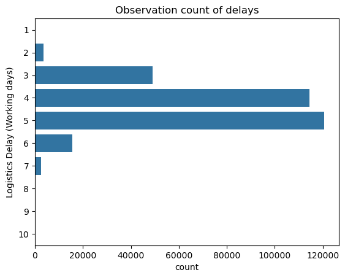

```python
fig, ax = plt.subplots()
sns.countplot(data = Logistics_delay, y = "Working_delay_days", ax = ax)
ax.set_ylabel("Logistics Delay (Working days)")
ax.set_title("Observation count of delays")
plt.show()
```

```python
display(Logistics_delay["Working_delay_days"].describe())   # V4 changes
skewness = Logistics_delay["Working_delay_days"].skew()
print(f"Skewness: {skewness:.4f}")
```

```
count   306,490.0000
mean          4.3435
std           0.8876
min           1.0000
25%           4.0000
50%           4.0000
75%           5.0000
max          10.0000
Name: Working_delay_days, dtype: float64
```

```
Skewness: 0.0312
```

The standard deviation is approximately 0.89. Therefore, the variance of approximately 0.79 is considerably smaller than the mean of approximately 4.34. Since a Poisson distribution requires its mean and variance to be equal, it appears unsuitable for the observed delays.

A discretized normal distribution seems more plausible because the count plot shows an approximately symmetric shape. This candidate distribution will therefore be evaluated using a statistical goodness-of-fit test. To support our assumption, the goodness-of-fit test is also used for the Poisson distribution.

A grouped Pearson $\chi^2$ test compares observed and expected frequencies in the groups ≤2, 3, 4, 5, 6, and ≥7 working days. The two estimated Normal parameters and the Poisson parameter are included in the degrees-of-freedom adjustment.

The Null hypothesis states that the observed delay frequencies are consistent with the respective candidate distribution. The alternative hypothesis states that they differ significantly.

```python
delays = Logistics_delay["Working_delay_days"].to_numpy()

test_edges = [-np.inf, 2.5, 3.5, 4.5, 5.5, 6.5, np.inf]
observed = np.histogram(delays, bins=test_edges)[0]


# Normal distribution
normal_mean, normal_std = stats.norm.fit(delays)

expected_normal = len(delays) * np.diff(
    stats.norm.cdf(
        test_edges,
        loc=normal_mean,
        scale=normal_std
    )
)

chi_normal, p_normal = stats.chisquare(
    observed,
    expected_normal,
    ddof=2
)


poisson_lambda = delays.mean()

expected_poisson = len(delays) * np.diff(
    stats.poisson.cdf(
        test_edges,
        mu=poisson_lambda
    )
)

chi_poisson, p_poisson = stats.chisquare(
    observed,
    expected_poisson,
    ddof=1
)


fit_test = pd.DataFrame(
    {
        "Distribution": ["Normal", "Poisson"],
        "Parameter 1": [normal_mean, poisson_lambda],
        "Parameter 2": [normal_std, np.nan],
        "Chi-square statistic": [chi_normal, chi_poisson],
        "p-value": [p_normal, p_poisson],
    }
)

display(fit_test)
```

|  | Distribution | Parameter 1 | Parameter 2 | Chi-square statistic | p-value |
| --- | --- | --- | --- | --- | --- |
| 0 | Normal | 4.3435 | 0.8876 | 9,864.3171 | 0.0000 |
| 1 | Poisson | 4.3435 | NaN | 250,429.5638 | 0.0000 |

The resulting p-values are effectively zero, so the test rejects an exact Normal and Poisson distribution. The chi-square statistic is substantially lower for the Normal distribution, indicating a closer fit to the grouped empirical frequencies than the Poisson distribution. With more than 300,000 observations, even small differences can be statistically significant.

However, the approximately symmetric shape, similar mean and median, and the very low skewness (0.0312) of the observed delay distribution indicate that the discretized Normal distribution provides a reasonable practical approximation. The fitted normal distribution plotted in 1.c (below) also shows that the Normal distribution provides a reasonable approximation to the observed distribution. It should not be interpreted as an exact probability model.

## 1b. Mean delay in working days

The arithmetic mean answers the question directly. The median is a robust description of a typical delivery, while the 95th percentile is useful for planning a service level.

```python
mean_delay = float(Logistics_delay["Working_delay_days"].mean())
median_delay = float(Logistics_delay["Working_delay_days"].median())
mode_delay = float(Logistics_delay["Working_delay_days"].mode()[0])
percentile_95 = float(
    Logistics_delay["Working_delay_days"].quantile(0.95)
)

delay_measures = pd.DataFrame(
    {
        "Measure": ["Mean", "Median", "Mode", "95th percentile"],
        "Working days": [
            mean_delay,
            median_delay,
            mode_delay,
            percentile_95,
        ],
    }
)
display(delay_measures)
```

|  | Measure | Working days |
| --- | --- | --- |
| 0 | Mean | 4.3435 |
| 1 | Median | 4.0000 |
| 2 | Mode | 5.0000 |
| 3 | 95th percentile | 6.0000 |

The mean logistics delay is approximately **4.34 working days**. This means that component K7 is received, on average, slightly more than four working days after its issue date.

The median is **4 working days**. This means that at least 50% of the observed deliveries have a delay of 4 working days or less. The median is a useful alternative to the mean because it is less sensitive to unusually large delays. In this case, the mean is slightly greater than the median, suggesting that a small number of longer delays increase the average.

The median is equivalent to the 50th percentile. Other percentiles can also be used to evaluate logistic delays, for example the number of working days within which 90% or 95% of deliveries arrive.

For example the 95th percentile is **6 working days**, meaning that at least 95% of deliveries take no more than six working days.

Another alternative is the mode, which is **5 working days**. This is the most frequently observed logistics delay and therefore represents the most common delivery outcome.

## 1c. Plotly histogram and density

The delay is recorded only in whole working days. Therefore, one-day bins centred on the integers are clearer than an automatic fractional bin width. The fitted Normal density is shown as a simple approximation and to visualize the normal approximation discussed in 1a.

```python
density_x = np.linspace(delays.min() - 0.5, delays.max() + 0.5, 400)

delay_figure = go.Figure()
delay_figure.add_trace(
    go.Histogram(
        x=delays,
        histnorm="probability density",
        xbins={
            "start": delays.min() - 0.5,
            "end": delays.max() + 0.5,
            "size": 1,
        },
        name="Observed delay",
        opacity=0.7,
    )
)
delay_figure.add_trace(
    go.Scatter(
        x=density_x,
        y=stats.norm.pdf(
            density_x, loc=normal_mean, scale=normal_std
        ),
        mode="lines",
        name="Fitted Normal density",
        line={"width": 3},
    )
)
delay_figure.update_layout(
    title="K7 logistics delay",
    xaxis_title="Logistics delay (working days)",
    yaxis_title="Probability density",
    template="plotly_white",
    bargap=0.05,
)
delay_figure.show("notebook")
```

[interactive chart not shown]

## 1d. Decision tree for defective K7 components

A decision tree needs a target variable, predictor variables, a training set, and a test set. The logistics extracts contain almost no positive defect labels, so the complete K7 component file is joined one-to-one to obtain the usable Fehlerhaft target. Potential predictors that are available by goods receipt include logistics delay, producer number, and plant number. Component IDs should not be used as predictors because they do not represent meaningful properties of the component.

```python
k7_target = pd.read_csv(
    DATA_ROOT / "Komponente" / "Komponente_K7.txt",
    sep="\t",
    usecols=["ID_Karosserie", "Fehlerhaft"],
    dtype={"ID_Karosserie": "string", "Fehlerhaft": "int8"},
).rename(
    columns={
        "ID_Karosserie": "IDNummer",
        "Fehlerhaft": "Defective",
    }
)

tree_data = Logistics_delay.merge(
    k7_target,
    on="IDNummer",
    how="left",
)


class_counts = (
    tree_data["Defective"]
    .value_counts()
    .rename(index={0: "Not defective", 1: "Defective"})
    .reset_index()
)

class_counts.columns = ["Class", "Count"]

fig = px.bar(
    class_counts,
    x="Class",
    y="Count",
    title="Distribution of defective and non-defective K7 components",
)

fig.show("notebook")
```

[interactive chart not shown]

While including the complete K7 component file increased the number of defective components, the distribution remains highly imbalanced, with substantially fewer defective than non-defective components. This class imbalance should be considered when constructing and evaluating a decision tree, particularly because accuracy alone can be misleading for imbalanced classes.

A decision tree recursively selects splits on the predictor variables that best separate the target classes, for example by maximizing information gain. Visualizing the distribution of the target variable across the considered predictors can therefore help identify variables and values that may provide useful splits and indicate a potential tree structure.

```python
delay_defect_rate = (
    tree_data
    .groupby("Working_delay_days")["Defective"]
    .mean()
    .reset_index()
)

fig = px.bar(
    delay_defect_rate,
    x="Working_delay_days",
    y="Defective",
    title="Defect rate by logistics delay",
    labels={
        "Working_delay_days": "Logistics delay (working days)",
        "Defective": "Defect rate",
    },
)

fig.show("notebook")
```

[interactive chart not shown]

```python
pd.DataFrame(tree_data.groupby("Working_delay_days").size())
```

| Working_delay_days | 0 |
| --- | --- |
| 1 | 5 |
| 2 | 3641 |
| 3 | 49017 |
| 4 | 114425 |
| 5 | 120690 |
| 6 | 15661 |
| 7 | 2666 |
| 8 | 337 |
| 9 | 40 |
| 10 | 8 |

The visualization of the defect rate across logistics delays shows noticeable differences for delays of 1, 8, and 9 working days. However, further investigation shows that these differences are most likely caused by the small number of observations for these particular delay values. Therefore, logistics delay does not appear to provide meaningful splitting information for the target variable.

```python
producer_defect_rate = (
    tree_data
    .groupby("Producer_number")["Defective"]
    .mean()
    .reset_index()
)

fig = px.bar(
    producer_defect_rate,
    x="Producer_number",
    y="Defective",
    title="Defect rate by producer",
    labels={
        "Producer_number": "Producer",
        "Defective": "Defect rate",
    },
)

fig.show()
```

[interactive chart not shown]

```python
corr = tree_data["Producer_number"].corr(tree_data["Plant_number"])   # V4 changes
print(f"Correlation of Producer_number and Plant_number: {corr}")
```

```
Correlation of Producer_number and Plant_number: 1.0
```

Regarding the producer number, the defect rate is almost identical across the two observed producer numbers in the dataset. Therefore, the producer number also does not appear to provide a meaningful split for the target variable. Furthermore, the correlation between producer number and plant number is 1.0, indicating a perfect positive linear relationship in the observed data. In this dataset, each producer number is therefore associated with a single plant number, so the plant number does not provide additional information.

### Decision tree construction

The model is created and assessed in five steps:

1. The target distribution is visualized to check the balance between defective and non-defective components.
2. Defect rates are compared across logistics delay and producer number to identify potentially useful predictors. Plant number is also considered, but it provides no additional information because it is perfectly correlated with producer number in this dataset.
3. The data is split into stratified training and test sets so that both sets retain the same class proportions.
4. A shallow decision tree is trained with balanced class weights to account for the strong class imbalance.
5. The predictions on the test set are evaluated using a confusion matrix, balanced accuracy, precision, recall, and F1 score. Ordinary accuracy alone would be misleading for the imbalanced target.

The preceding visualizations show that the available predictors provide little separation between the two classes. The resulting decision tree should therefore be interpreted as a demonstration of the modelling process rather than as a reliable defect classifier.

A simple implementation using sklearn is shown below.

| Defective | Components |
| --- | --- |
| Not defective | 275769 |
| Defective | 30721 |

|  | Test value |
| --- | --- |
| Balanced accuracy | 0.4957 |
| Precision | 0.0987 |
| Recall | 0.4941 |
| F1 score | 0.1645 |

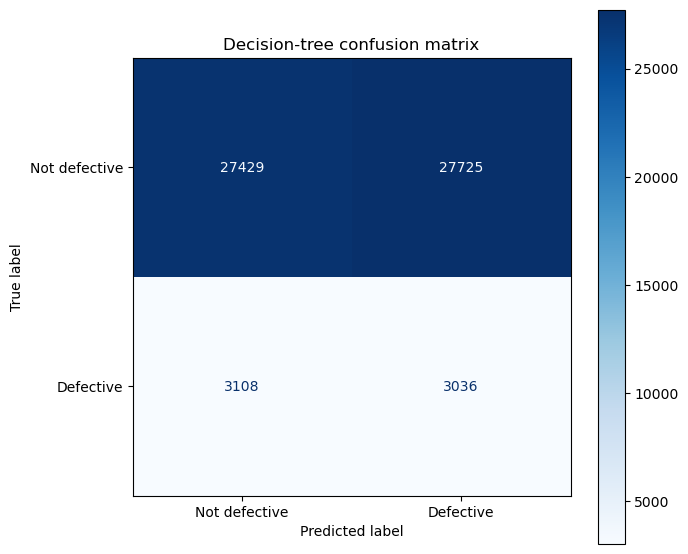

```python
k7_target = pd.read_csv(
    DATA_ROOT / "Komponente" / "Komponente_K7.txt",
    sep="\t",
    usecols=["ID_Karosserie", "Fehlerhaft"],
    dtype={"ID_Karosserie": "string", "Fehlerhaft": "int8"},
).rename(
    columns={
        "ID_Karosserie": "IDNummer",
        "Fehlerhaft": "Defective",
    }
)

tree_data = Logistics_delay.merge(
    k7_target,
    on="IDNummer",
    how="left",
)
X = tree_data[["Working_delay_days", "Producer_number", "Plant_number"]].copy()
X[["Producer_number", "Plant_number"]] = X[
    ["Producer_number", "Plant_number"]
].astype("string")
X = pd.get_dummies(
    X, columns=["Producer_number", "Plant_number"], dtype=int
)
y = tree_data["Defective"]

X_train, X_test, y_train, y_test = train_test_split(
    X,
    y,
    test_size=0.20,
    stratify=y,
    random_state=42,
)

defect_tree = DecisionTreeClassifier(
    max_depth=3,
    min_samples_leaf=500,
    class_weight="balanced",
    random_state=42,
)
defect_tree.fit(X_train, y_train)
tree_predictions = defect_tree.predict(X_test)

tree_metrics = pd.Series(
    {
        "Balanced accuracy": balanced_accuracy_score(
            y_test, tree_predictions
        ),
        "Precision": precision_score(
            y_test, tree_predictions
        ),
        "Recall": recall_score(
            y_test, tree_predictions
        ),
        "F1 score": f1_score(
            y_test, tree_predictions
        ),
    },
    name="Test value",
)
display(
    y.value_counts()
    .rename(index={0: "Not defective", 1: "Defective"})
    .rename("Components")
    .to_frame()
)
display(tree_metrics.to_frame())

fig, ax = plt.subplots(figsize=(7, 6))
ConfusionMatrixDisplay.from_predictions(
    y_test,
    tree_predictions,
    display_labels=["Not defective", "Defective"],
    cmap="Blues",
    ax=ax,
)
ax.set_title("Decision-tree confusion matrix")
plt.tight_layout()
plt.show()
```

### Decision rules as model output

The following rules are extracted directly from the fitted decision tree. This makes every split and predicted class reproducible without requiring a graphical tree visualization. Here, class 0 means **not defective** and class 1 means **defective**.

```python
tree_rules = export_text(
    defect_tree,
    feature_names=list(X.columns),
    decimals=1,
)
print(tree_rules)
```

```
|--- Working_delay_days <= 2.5
|   |--- Producer_number_114 <= 0.5
|   |   |--- class: 1
|   |--- Producer_number_114 >  0.5
|   |   |--- class: 0
|--- Working_delay_days >  2.5
|   |--- Plant_number_1132 <= 0.5
|   |   |--- Working_delay_days <= 3.5
|   |   |   |--- class: 1
|   |   |--- Working_delay_days >  3.5
|   |   |   |--- class: 1
|   |--- Plant_number_1132 >  0.5
|   |   |--- Working_delay_days <= 6.5
|   |   |   |--- class: 0
|   |   |--- Working_delay_days >  6.5
|   |   |   |--- class: 0
```

### Simplified interpretation

The trained decision tree can be summarized in plain language:

- For a logistics delay of **at most 2 working days**, components from producer 114 are predicted as **not defective**, while components from producer 112 are predicted as **defective**.
- For a logistics delay of **3 working days or more**, components from plant 1132 are predicted as **not defective**, while components from plant 1142 are predicted as **defective**.

The fitted tree contains additional delay splits, but they do not change the predicted class and are therefore omitted from this simplified description. The confusion matrix and the balanced accuracy of approximately **49.6%** show that these rules have very limited predictive value. They describe the fitted model, but they should not be interpreted as reliable defect patterns.

# 2. Data Storage in Separate Files

The files represent a **relational database structure**: separate tables describe parts, components, vehicles and registrations, and identifiers act as primary and foreign keys between them.

Benefits of separate related tables include:

1. **Less redundancy:** the same value does not need to be repeated in one huge table.
2. **Better consistency:** a fact is maintained in one authoritative place.
3. **Data integrity:** keys can be used to validate relationships.
4. **Simpler updates:** corrections do not need to be repeated across many rows.
5. **Maintainability:** tables can be extended independently.
6. **Access control and performance:** only required tables and columns need to be read.
7. **Organizational alignment:** each location manages only the data they are responsible for, reducing scope and preventing unintended cross-location modifications.

CSV is only the file format used to exchange these relational tables.

# 3. T16 Parts in Vehicles Registered in Adelshofen

T16 is an individual part used in seat components according to the data structure. Inspection of the component tables shows that T16 occurs in K2LE2 and K2ST2. Both components are referenced through ID_Sitze only in the OEM2 vehicle tables for Typ21 and Typ22. The required join path is therefore registered vehicle ID → seat-component ID → T16 ID.

```python
component_dir = DATA_ROOT / "Komponente"

t16_components = []

for path in component_dir.iterdir():

    with open(path, "r", encoding="utf-8") as f:
        header = f.readline()

    if "ID_T16" in header:
        t16_components.append(path.name)

t16_components
```

```
['Bestandteile_Komponente_K2LE2.csv', 'Bestandteile_Komponente_K2ST2.csv']
```

```python
vehicle_dir = DATA_ROOT / "Fahrzeug"

k2le2_files = []
k2st2_files = []

for path in vehicle_dir.glob("Bestandteile_Fahrzeuge_*.csv"):

    vehicle_data = pd.read_csv(
        path,
        sep=";",
        usecols=["ID_Sitze"],
        dtype="string",
    )
    if vehicle_data["ID_Sitze"].str.startswith("K2LE2").any():
        k2le2_files.append(path.name)
    if vehicle_data["ID_Sitze"].str.startswith("K2ST2").any():
        k2st2_files.append(path.name)

k2le2_files, k2st2_files
```

```
(['Bestandteile_Fahrzeuge_OEM2_Typ21.csv',
  'Bestandteile_Fahrzeuge_OEM2_Typ22.csv'],
 ['Bestandteile_Fahrzeuge_OEM2_Typ21.csv',
  'Bestandteile_Fahrzeuge_OEM2_Typ22.csv'])
```

```python
registration_path = DATA_ROOT / "Zulassungen" / "Zulassungen_alle_Fahrzeuge.csv"
adelshofen_vehicle_ids = set(read_matches(
    registration_path,
    ["IDNummer", "Gemeinden"],
    "Gemeinden",
    {"ADELSHOFEN"},
)["IDNummer"])

oem2_seats = pd.concat(
    (
        read_matches(
            DATA_ROOT / "Fahrzeug" / f"Bestandteile_Fahrzeuge_OEM2_{vehicle_type}.csv",
            ["ID_Fahrzeug", "ID_Sitze"],
            "ID_Fahrzeug",
            adelshofen_vehicle_ids,
        )
        for vehicle_type in ["Typ21", "Typ22"]
    ),
    ignore_index=True,
)

t16_parts = pd.concat(
    (
        read_matches(
            DATA_ROOT / "Komponente" / f"Bestandteile_Komponente_{component}.csv",
            [f"ID_{component}", "ID_T16"],
            f"ID_{component}",
            set(oem2_seats.loc[oem2_seats["ID_Sitze"].str.startswith(component), "ID_Sitze"]),
        )
        for component in ["K2LE2", "K2ST2"]
    ),
    ignore_index=True,
)
t16_count = t16_parts["ID_T16"].nunique()
display(Markdown(f"Answer: {t16_count} T16 parts did finally end up in vehilces registered in Adelshofen."))
```

Answer: 48 T16 parts did finally end up in vehilces registered in Adelshofen.

# 4. Attributes of the Registration Table

| Attribute | Pandas data type | Semantic type | Characteristics |
| --- | --- | --- | --- |
| Unnamed: 0 | int64 | Technical index | Row number created during CSV export; not a business attribute. |
| IDNummer | string | Nominal identifier | Vehicle key used for equality and joins; arithmetic is meaningless. |
| Gemeinden | category | Nominal categorical | Unordered municipality names; counts and groups are meaningful. |
| Zulassung | datetime64 | Date / temporal | Ordered values; date filtering and differences are meaningful. The stored precision (ns or us) depends on the Pandas version. |

Identifiers should be stored as strings even if they contain digits because their formatting is meaningful. Registration dates should be parsed as dates rather than kept as generic text.

```python
registration_sample = pd.read_csv(
    registration_path, sep=";", nrows=10000
)
registration_sample = registration_sample.astype(
    {"IDNummer": "string", "Gemeinden": "category"}
)
registration_sample["Zulassung"] = pd.to_datetime(
    registration_sample["Zulassung"], format="%Y-%m-%d"
)
display(
    registration_sample.dtypes.astype(str)
    .rename("Observed Pandas dtype")
    .to_frame()
)
```

|  | Observed Pandas dtype |
| --- | --- |
| Unnamed: 0 | int64 |
| IDNummer | string |
| Gemeinden | category |
| Zulassung | datetime64[us] |

# 5. Linear Model for Mileage

Failure mileage (Fehlerhaft_Fahrleistung) is modelled using fuel and the categorical engine class. The exploratory correlation matrix and scatter plot are used to assess the available predictors. fuel has a clear association with failure mileage, while days has almost no linear association (correlation approximately 0.002) and is therefore not included in this linear model. Engine class is retained as a categorical predictor because vehicles from the three classes may have different baseline mileage levels. A train/test split evaluates predictive performance on unseen data.

The model is:

$$ \text{failure mileage} = \beta_0 + \beta_1 \cdot \text{fuel} + \text{engine-class effects} + \varepsilon. $$

```python
mileage_data = pd.read_csv(
    DATA_ROOT
    / "Fahrzeug"
    / "Fahrzeuge_OEM1_Typ11_Fehleranalyse.csv",
    sep=",",
    usecols=[
        "Fehlerhaft_Fahrleistung",
        "days",
        "fuel",
        "engine",
    ],
)

display(
    mileage_data[
        ["Fehlerhaft_Fahrleistung", "days", "fuel"]
    ].corr()
)

plot_sample = mileage_data.sample(
    n=2000, random_state=42
)
px.scatter(
    plot_sample,
    x="fuel",
    y="Fehlerhaft_Fahrleistung",
    color="engine",
    trendline="ols",
    render_mode="svg",
    opacity=0.35,
    title="Failure mileage versus fuel by engine class",
    labels={
        "Fehlerhaft_Fahrleistung": "Failure mileage"
    },
    template="plotly_white",
).show("notebook")
```

|  | Fehlerhaft_Fahrleistung | days | fuel |
| --- | --- | --- | --- |
| Fehlerhaft_Fahrleistung | 1.0000 | 0.0017 | 0.6896 |
| days | 0.0017 | 1.0000 | 0.0042 |
| fuel | 0.6896 | 0.0042 | 1.0000 |

[interactive chart not shown]

```python
mileage_train, mileage_test = train_test_split(
    mileage_data,
    test_size=0.20,
    random_state=42,
)
mileage_formula = (
    "Fehlerhaft_Fahrleistung ~ fuel + "
    "C(engine, Treatment(reference='small'))"
)

train_model = smf.ols(
    mileage_formula, data=mileage_train
).fit()
test_predictions = train_model.predict(mileage_test)

model_metrics = pd.Series(
    {
        "Test R2": r2_score(
            mileage_test["Fehlerhaft_Fahrleistung"],
            test_predictions,
        ),
        "Test RMSE": np.sqrt(
            mean_squared_error(
                mileage_test["Fehlerhaft_Fahrleistung"],
                test_predictions,
            )
        ),
    },
    name="Value",
)
display(model_metrics.to_frame())

mileage_model = smf.ols(
    mileage_formula, data=mileage_data
).fit()
coefficient_table = (
    mileage_model.params.rename("Coefficient").to_frame()
)
display(coefficient_table)

typical_vehicle = (
    mileage_data.groupby("engine", as_index=False)["fuel"]
    .median()
    .rename(columns={"fuel": "Median fuel"})
)
typical_vehicle["Predicted failure mileage"] = (
    mileage_model.predict(
        typical_vehicle.rename(
            columns={"Median fuel": "fuel"}
        )
    )
)
display(typical_vehicle)
```

|  | Value |
| --- | --- |
| Test R2 | 0.4900 |
| Test RMSE | 11,114.0719 |

|  | Coefficient |
| --- | --- |
| Intercept | 20,678.6257 |
| C(engine, Treatment(reference='small'))[T.large] | -11,161.5098 |
| C(engine, Treatment(reference='small'))[T.medium] | -3,313.3980 |
| fuel | 5,235.1673 |

|  | engine | Median fuel | Predicted failure mileage |
| --- | --- | --- | --- |
| 0 | large | 11.4458 | 69,437.6882 |
| 1 | medium | 8.0239 | 59,371.8103 |
| 2 | small | 3.8314 | 40,736.4948 |

**Model interpretation and recommendations for OEM1.**

- fuel has the strongest relationship with failure mileage in the model. For vehicles of the same engine class, an increase of one unit in fuel is associated with about **5,235 additional mileage units** before failure.
- The predicted failure mileage also differs between engine classes. At the median fuel value of each class, the model predicts about **40,736 for small**, **59,372 for medium**, and **69,438 for large** engines. This suggests that using different maintenance intervals for the engine classes could make more sense than using one fixed interval for all vehicles.
- These values should not be treated as exact failure points. They are average predictions, so individual vehicles can fail considerably earlier or later.
- With a test R² of about **0.49** and an RMSE of around **11,114**, the model explains a reasonable part of the differences in failure mileage, but there is still a lot it cannot explain. Other information such as maintenance history, driving behaviour or operating conditions could improve the model.
- Finally, the relationship between fuel and failure mileage should not be interpreted as causal. The model only shows that the two variables are related in the available data.

# 6. Hit-and-Run Accident Investigation

The exact body-part ID is first looked up to its vehicle in the OEM1 Type 12 component table. That vehicle ID is matched to the table with the registrations. Only registrations are relevant on or before 11 August 2010 for our check.

```python
body_part_id = "K5-112-1122-79"
accident_date = pd.Timestamp("2010-08-11")

hit_vehicle = read_matches(
    DATA_ROOT
    / "Fahrzeug"
    / "Bestandteile_Fahrzeuge_OEM1_Typ12.csv",
    ["ID_Karosserie", "ID_Fahrzeug"],
    "ID_Karosserie",
    {body_part_id},
)
hit_vehicle_id = hit_vehicle.iloc[0]["ID_Fahrzeug"]

hit_registration = read_matches(
    registration_path,
    ["IDNummer", "Gemeinden", "Zulassung"],
    "IDNummer",
    {hit_vehicle_id},
)
hit_registration["Zulassung"] = pd.to_datetime(
    hit_registration["Zulassung"], format="%Y-%m-%d"
)
valid_registration = hit_registration.loc[
    hit_registration["Zulassung"] <= accident_date
].sort_values("Zulassung")
accident_registration = valid_registration.iloc[-1]

hit_location = accident_registration["Gemeinden"]
investigation_result = pd.DataFrame(
    {
        "Body part": [body_part_id],
        "Vehicle": [hit_vehicle_id],
        "Registration date": [
            accident_registration["Zulassung"].date()
        ],
        "Municipality": [hit_location],
    }
)
display(investigation_result)
display(
    Markdown(
        f"Answer: On 11 August 2010, the vehicle was "
        f"registered in {hit_location.title()}."
    )
)
```

|  | Body part | Vehicle | Registration date | Municipality |
| --- | --- | --- | --- | --- |
| 0 | K5-112-1122-79 | 12-1-12-82 | 2009-01-02 | ASCHERSLEBEN |

Answer: On 11 August 2010, the vehicle was registered in Aschersleben.

The damaged body part K5-112-1122-79 is traced to vehicle 12-1-12-82, which we can see was  
registered in **Aschersleben** on 2 Jan 2009. Since this registration is before the 11 Aug 2010 accident, we can still expect the vehicle to be a possible suspect.